# Final Project: Image Classification

Damian Etchevest, Franke, Max

Course: CIS-544 DATA MINING & MACHINE LRNG

Term: SpringT1

Last modified date: 02/24/2020

# Image classification, is it a car?

## Workspace preparation

### Approach

In this section the workspace will be prepared. This means that first the global environment will be cleaned, and all required packages will be loaded. The data should hosted in a bucket in the aws Cloud and is loaded into R via a SQL connection. The data should transformed into R accordingly (ELT). Because of connection errors, first the models are trained with a subset of the data.

### Clean Workspace

```r
rm(list = ls())
```

### Install libraries

```r
#install.packages("tidyverse")
#install.packages("lubridate")
#install.packages("rockchalk")
#install.packages("corrplot")
#install.packages("ggcorrplot")
#install.packages("e1071")
#install.packages("ROCR")
#install.packages("rpart")
#install.packages("rpart.plot")
#install.packages("caTools")
#install.packages("party")
#install.packages("knitr")
#install.packages("rmarkdown")
#install.packages("forecast")
#install.packages("RMySQL")
#install.packages("DBI")
#install.packages("dplyr")
```

### Load Packages

```r
library(tidyverse)
library(lubridate)
library(rockchalk)
library(zoo)
library(corrplot)
library(e1071)
library(ROCR)
library(rpart)
library(rpart.plot)
library(caTools)
library(party)
library(knitr)
library(rmarkdown)
library(forecast)
library(RMySQL)
library(DBI)
library(dplyr)
library(readr)
library(randomForest)
library(neuralnet)
library(kernlab)
#BiocManager::install(pkgs = "EBImage")
library(EBImage)
```

### Establish Connection to data

```r
# Classes
class_descriptions_boxable <- read_csv("https://storage.googleapis.com/openimages/v5/class-descriptions-boxable.csv", col_names = FALSE)
colnames(class_descriptions_boxable) <- c("ID", "class")

# Load the annotations
train_annotations_object_segmentation <- read_csv("https://storage.googleapis.com/openimages/v5/train-annotations-object-segmentation.csv")
head(train_annotations_object_segmentation)
```

| MaskPath | ImageID | LabelName | BoxID | BoxXMin | BoxXMax | BoxYMin | BoxYMax | PredictedIoU | Clicks |
| --- | --- | --- | --- | --- | --- | --- | --- | --- | --- |
| 677c122b0eaa5d16_m04yx4_9a041d52.png | 677c122b0eaa5d16 | /m/04yx4 | 9a041d52 | 0.887500 | 0.960938 | 0.454167 | 0.720833 | 0.86864 | 0.95498 0.65197 1;0.89370 0.56579 1;0.94701 0.48968 0;0.91049 0.70010 1;0.93927 0.47160 1;0.90269 0.56068 0;0.92061 0.70749 0;0.92509 0.64628 0;0.92248 0.65188 1;0.93042 0.46071 1;0.93290 0.71142 1;0.… |
| 05529ae018130c68_m09j2d_b1115fd0.png | 05529ae018130c68 | /m/09j2d | b1115fd0 | 0.086875 | 0.254375 | 0.504708 | 0.790960 | 0.80250 | 0.16388 0.50114 1;0.25069 0.75425 1;0.13478 0.67270 0;0.13478 0.51730 0;0.14134 0.73927 0;0.17918 0.68295 1;0.22580 0.63150 0;0.11365 0.51121 1;0.23104 0.61840 1;0.09115 0.52401 0;0.14678 0.68757 1 |
| 96e7ee70b428a54e_m04yx4_05580497.png | 96e7ee70b428a54e | /m/04yx4 | 05580497 | 0.456250 | 0.603125 | 0.222013 | 0.903104 | 0.55850 | 0.52271 0.46625 0;0.52695 0.70150 0;0.59151 0.88178 1;0.49977 0.26807 1;0.48395 0.28952 0;0.55182 0.36076 1;0.50092 0.74922 1;0.58754 0.59330 0;0.50099 0.66845 1;0.56294 0.60185 1;0.50788 0.37395 1;0.… |
| 76084f166740d78a_m09j2d_557dfcf5.png | 76084f166740d78a | /m/09j2d | 557dfcf5 | 0.018750 | 0.145625 | 0.313333 | 0.754167 | 0.62394 | 0.08756 0.34082 0;0.03971 0.34195 1;0.06705 0.65066 1;0.12771 0.66433 0;0.03228 0.40017 0;0.05536 0.72212 1;0.09264 0.65702 0;0.12371 0.75171 0;0.07303 0.36018 1;0.09183 0.64838 0;0.12515 0.33626 1;0.… |
| ebaccfc70c721055_m02p0tk3_b39109c0.png | ebaccfc70c721055 | /m/02p0tk3 | b39109c0 | 0.097500 | 0.212500 | 0.291667 | 0.930833 | 0.84223 | 0.19847 0.85413 1;0.18916 0.34751 1;0.18636 0.91125 1;0.12769 0.56357 1;0.18938 0.31802 0;0.20325 0.89001 0;0.21415 0.84377 1;0.18839 0.43030 1;0.20451 0.88019 0;0.19936 0.79429 0;0.19764 0.40491 0;0.… |
| b98e54a313c0aff2_m05r655_d190fb32.png | b98e54a313c0aff2 | /m/05r655 | d190fb32 | 0.220000 | 0.531250 | 0.417293 | 0.868421 | 0.77126 | 0.41474 0.54724 0;0.26495 0.87520 1;0.42708 0.71803 1;0.52172 0.81332 1;0.48746 0.84475 1;0.33668 0.78366 1;0.40228 0.58122 1;0.30193 0.42369 1;0.37643 0.67501 1;0.43013 0.58724 1;0.34491 0.82685 1;0.… |

### Transforming the images

```r
# set wd
setwd("/Users/MaxFranke/Desktop/05_Big Data Analytics/04_Classes/03 SP:Term1/CIS-544 DATA MINING & MACHINE LRNG/06_Final_Project/ImageClassification/ImageClassification/01_Data/")
```

```
The working directory was changed to /Users/MaxFranke/Desktop/05_Big Data Analytics/04_Classes/03 SP:Term1/CIS-544 DATA MINING & MACHINE LRNG/06_Final_Project/ImageClassification/ImageClassification/01_Data inside a notebook chunk. The working directory will be reset when the chunk is finished runni…
```

```r
# Storing the files
files <- list.files(path = "train-masks-0")
head(files)
```

```
[1] "0000048549557964_m0k4j_0f7c02af.png"  "0000048549557964_m0k4j_1232f6e4.png"  "0000048549557964_m0k4j_22dcf663.png"
[4] "0000048549557964_m0k4j_d5cba825.png"  "0000048549557964_m0pg52_93cba453.png" "0000048549557964_m0pg52_9cfc84ed.png"
```

### Create dataframe with all Pixels, ImageID’s, LabelNames, and class

[output not shown]

[output cut: 990 more lines]

## Model Building & Prediction

### Approach

In this section the models are build to answer if the picture is a Car. So, we want to predict if a picture from the data is a “Car” or not? The following models are built:

1. Naïve Bayes
2. Random Forest
3. Deep Learning
4. Support Vector Machines

Finally, the models are predicted in conjunction with the test data set.

### Transform dataset

```r
# We want to predict if the class == "Car" or not
images <- subset(result[,c(4:103)])
images$class <- if_else(result$class == "Car", 1, 0)
images <- images[,c(101, 1:100)]

# Save as factor
names(images) <- make.names(names(images))
images$class <- as.factor(images$class)
head(images)
```

|  | class | Pixel.1 | Pixel.2 | Pixel.3 | Pixel.4 | Pixel.5 | Pixel.6 | Pixel.7 | Pixel.8 | Pixel.9 | Pixel.10 | Pixel.11 | Pixel.12 | Pixel.13 | Pixel.14 | Pixel.15 | Pixel.16 | Pixel.17 | Pixel.18 | Pixel.19 | Pixel.20 | Pixel.21 | Pixel.22 | Pixel.23 | Pixel.24 | Pixel.25 | Pixel.26 | Pixel.27 | Pixel.28 | … |
| --- | --- | --- | --- | --- | --- | --- | --- | --- | --- | --- | --- | --- | --- | --- | --- | --- | --- | --- | --- | --- | --- | --- | --- | --- | --- | --- | --- | --- | --- | --- |
| 1 | 1 | 0 | 0 | 0 | 0 | 0 | 0 | 0 | 0 | 0 | 0 | 0 | 0 | 0 | 0 | 0 | 0 | 0 | 0 | 0 | 0 | 0 | 0 | 0 | 0 | 0 | 0 | 0 | 0.0 | … |
| 2 | 1 | 0 | 0 | 0 | 0 | 0 | 0 | 0 | 0 | 0 | 0 | 0 | 0 | 0 | 0 | 0 | 0 | 0 | 0 | 0 | 0 | 0 | 0 | 0 | 0 | 0 | 0 | 0 | 0.0 | … |
| 3 | 1 | 0 | 0 | 0 | 0 | 0 | 0 | 0 | 0 | 0 | 0 | 0 | 0 | 0 | 0 | 0 | 0 | 0 | 0 | 0 | 0 | 0 | 0 | 0 | 0 | 0 | 0 | 0 | 0.5 | … |
| 4 | 1 | 0 | 0 | 0 | 0 | 0 | 0 | 0 | 0 | 0 | 0 | 0 | 0 | 0 | 0 | 0 | 0 | 0 | 0 | 0 | 0 | 0 | 0 | 0 | 0 | 0 | 0 | 0 | 0.0 | … |
| 5 | 0 | 0 | 0 | 0 | 0 | 0 | 0 | 0 | 0 | 0 | 0 | 0 | 0 | 0 | 0 | 0 | 0 | 0 | 0 | 0 | 0 | 0 | 0 | 0 | 0 | 0 | 0 | 0 | 0.0 | … |
| 6 | 0 | 0 | 0 | 0 | 0 | 0 | 0 | 0 | 0 | 0 | 0 | 0 | 0 | 0 | 0 | 0 | 0 | 0 | 0 | 0 | 0 | 0 | 0 | 0 | 0 | 0 | 0 | 0 | 0.0 | … |

### Create training and test data

```r
require(caTools)

# Set the random seed for repeatability
set.seed(123)

# Split the data into Ratio 3:1
sample <- sample.split(images$class, SplitRatio = .75)
train <- subset(images, sample == TRUE)
test <- subset(images, sample == FALSE)

# Data sets with all independent variables for training the dependent variable "Revenue"
train_x <- train[,-which(names(train) %in% "class")]
train_y <- factor(train$class)

# Data sets with all independent variables for test the dependent variable "Revenue"
test_x <- test[,-which(names(test) %in% "class")]
test_y <- factor(test$class)
```

### Naive Bayes

```r
nb_model <- naiveBayes(class ~ ., data = train, laplace = 5)
nb_model
```

```
Naive Bayes Classifier for Discrete Predictors

Call:
naiveBayes.default(x = X, y = Y, laplace = laplace)

A-priori probabilities:
Y
         0          1
0.93912265 0.06087735

Conditional probabilities:
   Pixel.1
Y         [,1]      [,2]
  0 0.01487131 0.1210493
  1 0.03933824 0.1929011

   Pixel.2
Y         [,1]      [,2]
  0 0.02040038 0.1413790
  1 0.03998529 0.1943936

   Pixel.3
Y         [,1]      [,2]
  0 0.02854147 0.1662805
  1 0.06176471 0.2410825

   Pixel.4
Y         [,1]      [,2]
  0 0.03703527 0.1885087
  1 0.07794118 0.2670971

   Pixel.5
Y         [,1]      [,2]
  0 0.04978074 0.2171987
  1 0.09117647 0.2882842

   Pixel.6
Y         [,1]      [,2]
  0 0.05403241 0.2253275
  1 0.11176471 0.3155411
```

[output cut: 455 more lines]

```

   Pixel.98
Y         [,1]      [,2]
  0 0.05142040 0.2206977
  1 0.06764706 0.2515094

   Pixel.99
Y         [,1]      [,2]
  0 0.04688275 0.2112206
  1 0.05455882 0.2258412

   Pixel.100
Y         [,1]      [,2]
  0 0.03834986 0.1918094
  1 0.04411765 0.2056591
```

### Random Forest

```r
# Rf model
rf_model <-  randomForest(class ~ ., data = train, method = "class")
rf_model
```

```
Call:
 randomForest(formula = class ~ ., data = train, method = "class")
               Type of random forest: classification
                     Number of trees: 500
No. of variables tried at each split: 10

        OOB estimate of  error rate: 6.14%
Confusion matrix:
     0  1 class.error
0 5235 10 0.001906578
1  333  7 0.979411765
```

### Deep Learning (neuralnet)

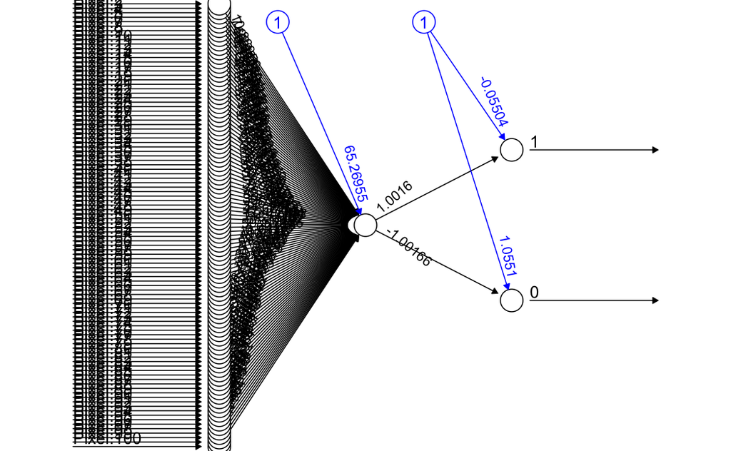

```r
nn_model <- neuralnet(formula = class ~ ., data = train)
plot(nn_model)
```

### Support Vector Machine

```r
svm_model <- ksvm(class ~ ., data = train, kernel = "vanilladot", prob.model = TRUE)
```

```
maximum number of iterations reached 0.004443532 0.004263754
```

```r
svm_model
```

```
Support Vector Machine object of class "ksvm"

SV type: C-svc  (classification)
 parameter : cost C = 1

Linear (vanilla) kernel function.

Number of Support Vectors : 1449

Objective Function Value : -679.9995
Training error : 0.060877
Probability model included.
```

### Prediction

```r
pred_test_nb <- predict(nb_model, newdata = test, type = "class")
pred_test_rf <- predict(rf_model, newdata = test, type = "class")
pred_test_nn <- compute(nn_model, test[2:101])$net.result
pred_test_nn <- pred_test_nn[,2]
pred_test_svm <- predict(svm_model, newdata = test)
```

### Summary

In naive bayes model, laplace is 5 to reduce the effect of unavailable records in the train set.

The random forest model makes 500 number of trees in the building process.

The deep learning neural net shows the weights and output layer.

The support vector machine works with the kernel “vanilladot”

## Performance Measurement

### Approach

In this section the models are evaluated according two criteria Accuracy & AUC values, whereby the decision for the best model is made on the basis of Accuracy. In order to calculate the accuracy, the confusion matrixes are first established, whereby the predictions still have to be transformed with regard to the “nerual net” model into “1” and “0”. Using the elements of the confusion matrix (TP,TN,FP,FN) and the other results (Actual and Prediction data frame), the accuracy is calculated and presented. Finally, it is examined whether there is a significant difference between the models with regard to accuracy.

### Confusion matrix

```r
# Confusion Matrix [neural net shows probabilities and is not useful to be displayed now]
nb_confusion_matrix <- table(test$class, pred_test_nb, dnn = c("Actual", "Prediction"))
rf_confusion_matrix <- table(test$class, pred_test_rf, dnn = c("Actual", "Prediction"))
#nn_confusion_matrix <- table(test$class, pred_test_nn, dnn = c("Actual", "Prediction"))
svm_confusion_matrix <- table(test$class, pred_test_svm, dnn = c("Actual", "Prediction"))

# Print
print(nb_confusion_matrix)
```

```
      Prediction
Actual    0    1
     0 1444  304
     1   83   31
```

```r
print(rf_confusion_matrix)
```

```
      Prediction
Actual    0    1
     0 1745    3
     1  113    1
```

```r
#print(nn_confusion_matrix)
print(svm_confusion_matrix)
```

```
      Prediction
Actual    0    1
     0 1748    0
     1  114    0
```

### Output results

```r
nb_results <- data.frame(Actual = test$class,
                          Prediction = pred_test_nb)

rf_results <- data.frame(Actual = test$class,
                          Prediction = pred_test_rf)

nn_results <- data.frame(Actual = test$class,
                          Prediction = pred_test_nn)
svm_results <- data.frame(Actual = test$class,
                          Prediction = pred_test_svm)
print(nb_results)
```

| Actual | Prediction |
| --- | --- |
| 1 | 0 |
| 1 | 0 |
| 0 | 0 |
| 0 | 0 |
| 0 | 0 |
| 0 | 0 |
| 0 | 0 |
| 0 | 1 |
| 0 | 0 |
| 0 | 0 |

[output cut: 990 more lines]

```r
print(rf_results)
```

|  | Actual | Prediction |
| --- | --- | --- |
| 2 | 1 | 0 |
| 4 | 1 | 0 |
| 6 | 0 | 0 |
| 7 | 0 | 0 |
| 8 | 0 | 0 |
| 11 | 0 | 0 |
| 20 | 0 | 0 |
| 22 | 0 | 0 |
| 24 | 0 | 0 |
| 32 | 0 | 0 |

[output cut: 990 more lines]

```r
print(nn_results)
```

|  | Actual | Prediction |
| --- | --- | --- |
| 2 | 1 | 0.05343704 |
| 4 | 1 | 0.05343704 |
| 6 | 0 | 0.05343704 |
| 7 | 0 | 0.05343704 |
| 8 | 0 | 0.05343704 |
| 11 | 0 | 0.05343704 |
| 20 | 0 | 0.05343704 |
| 22 | 0 | 0.05343704 |
| 24 | 0 | 0.05343704 |
| 32 | 0 | 0.05343704 |

[output cut: 990 more lines]

```r
print(svm_results)
```

| Actual | Prediction |
| --- | --- |
| 1 | 0 |
| 1 | 0 |
| 0 | 0 |
| 0 | 0 |
| 0 | 0 |
| 0 | 0 |
| 0 | 0 |
| 0 | 0 |
| 0 | 0 |
| 0 | 0 |

[output cut: 990 more lines]

### Transform Prediction for neural net

```r
nn_results$Prediction <- if_else(nn_results$Prediction > 0.5, 1, 0)
nn_results
```

|  | Actual | Prediction |
| --- | --- | --- |
| 2 | 1 | 0 |
| 4 | 1 | 0 |
| 6 | 0 | 0 |
| 7 | 0 | 0 |
| 8 | 0 | 0 |
| 11 | 0 | 0 |
| 20 | 0 | 0 |
| 22 | 0 | 0 |
| 24 | 0 | 0 |
| 32 | 0 | 0 |

[output cut: 990 more lines]

### Accuracy calculation

#### Naive Bayes

```r
# Elements of confusion matrix
TP <- nb_confusion_matrix[2,2]
TN <- nb_confusion_matrix[1,1]
FN <- nb_confusion_matrix[1,2]
FP <- nb_confusion_matrix[2,1]
# Calculate accuracy, precision, recall
nb_accuracy <- (TP+TN)/sum(TP, TN, FN, FP)
nb_precision <- (TP)/(TP+FP)
nb_recall <- (TP)/(TP+FN)
# Output results
cat("Accuracy for Naive Bayes is: ", nb_accuracy, "\n")
```

```
Accuracy for Naive Bayes is:  0.792159
```

```r
cat("Precision for Naive Bayes is: ", nb_precision, "\n")
```

```
Precision for Naive Bayes is:  0.2719298
```

```r
cat("Recall for Naive Bayes is: ", nb_recall, "\n")
```

```
Recall for Naive Bayes is:  0.09253731
```

```r
# Save Accuracy for Naive Bayes
nb_TP <- if_else(nb_results$Actual == nb_results$Prediction, 1, 0)
nb_TP <- as.data.frame(nb_TP)
nb_TP$Model <- "Naive Bayes"
names(nb_TP)[1] <- "Accuracy"
```

#### Random Forest

```r
# Elements of confusion matrix
TP <- rf_confusion_matrix[2,2]
TN <- rf_confusion_matrix[1,1]
FN <- rf_confusion_matrix[1,2]
FP <- rf_confusion_matrix[2,1]
# Calculate accuracy, precision, recall
rf_accuracy <- (TP+TN)/sum(TP, TN, FN, FP)
rf_precision <- (TP)/(TP+FP)
rf_recall <- (TP)/(TP+FN)
# Output results
cat("Accuracy for random forest is: ", rf_accuracy, "\n")
```

```
Accuracy for random forest is:  0.9377014
```

```r
cat("Precision for random forest is: ", rf_precision, "\n")
```

```
Precision for random forest is:  0.00877193
```

```r
cat("Recall for random forest is: ", rf_recall, "\n")
```

```
Recall for random forest is:  0.25
```

```r
# Save Accuracy for random forest
rf_TP <- if_else(rf_results$Actual == rf_results$Prediction, 1, 0)
rf_TP <- as.data.frame(rf_TP)
rf_TP$Model <- "Random Forest"
names(rf_TP)[1] <- "Accuracy"
```

#### Neural net

```r
# Elements of confusion matrix
TP <- nrow(subset(nn_results, Actual == 1 & Prediction == 1))
TN <- nrow(subset(nn_results, Actual == 0 & Prediction == 0))
FN <- nrow(subset(nn_results, Actual == 0 & Prediction == 1))
FP <- nrow(subset(nn_results, Actual == 1 & Prediction == 0))
# Calculate accuracy, precision, recall
nn_accuracy <- (TP+TN)/sum(TP, TN, FN, FP)
nn_precision <- (TP)/(TP+FP)
nn_recall <- (TP)/(TP+FN)
# Output results
cat("Accuracy for neural net is: ", nn_accuracy, "\n")
```

```
Accuracy for neural net is:  0.933942
```

```r
cat("Precision for neural net is: ", nn_precision, "\n")
```

```
Precision for neural net is:  0.00877193
```

```r
cat("Recall for neural net is: ", nn_recall, "\n")
```

```
Recall for neural net is:  0.09090909
```

```r
# Save Accuracy for Neural net
nn_TP <- if_else(nn_results$Actual == nn_results$Prediction, 1, 0)
nn_TP <- as.data.frame(nn_TP)
nn_TP$Model <- "Neural Net"
names(nn_TP)[1] <- "Accuracy"
```

#### Support Vector Machine

```r
# Elements of confusion matrix
TP <- svm_confusion_matrix[2,2]
TN <- svm_confusion_matrix[1,1]
FN <- svm_confusion_matrix[1,2]
FP <- svm_confusion_matrix[2,1]
# Calculate accuracy, precision, recall
svm_accuracy <- (TP+TN)/sum(TP, TN, FN, FP)
svm_precision <- (TP)/(TP+FP)
svm_recall <- (TP)/(TP+FN)
# Output results
cat("Accuracy for support vector machine is: ", svm_accuracy, "\n")
```

```
Accuracy for support vector machine is:  0.9387755
```

```r
cat("Precision for support vector machine is: ", svm_precision, "\n")
```

```
Precision for support vector machine is:  0
```

```r
cat("Recall for support vector machine is: ", svm_recall, "\n")
```

```
Recall for support vector machine is:  NaN
```

```r
# Save Accuracy for Support Vector Machine
svm_TP <- if_else(svm_results$Actual == svm_results$Prediction, 1, 0)
svm_TP <- as.data.frame(svm_TP)
svm_TP$Model <- "Support Vector Machine"
names(svm_TP)[1] <- "Accuracy"
```

### Accuracy comparison

```r
compare <- data.frame(Method = c("01-Naive Bayes", "02-Random Forest", "03-Neural Net", "04-Support Vector Machine"),
                      Accuracy = c(nb_accuracy, rf_accuracy, nn_accuracy, svm_accuracy))
compare
```

| Method | Accuracy |
| --- | --- |
| 01-Naive Bayes | 0.7921590 |
| 02-Random Forest | 0.9377014 |
| 03-Neural Net | 0.9339420 |
| 04-Support Vector Machine | 0.9387755 |

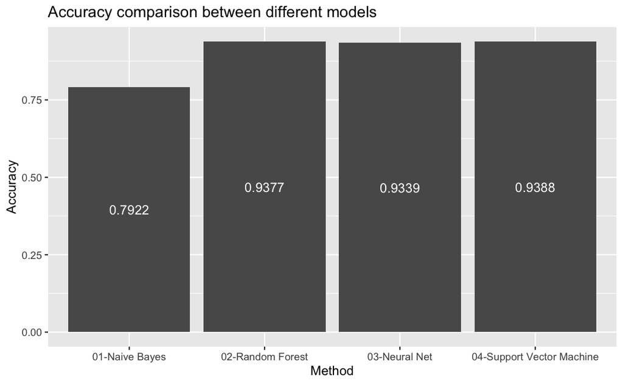

```r
ggplot(data = compare, mapping = aes(x = Method, y = Accuracy)) +
  geom_col() +
  geom_text(aes(label = round(Accuracy, 4)), position = position_stack(vjust = 0.5), col = "white") +
  labs(title = "Accuracy comparison between different models")
```

```r
TruePositive <- rbind(nb_TP, rf_TP, nn_TP, svm_TP)
TruePositive <- as.data.frame(TruePositive)
TruePositive$Model <- as.factor(TruePositive$Model)
aov <- aov(Accuracy ~ Model, data = TruePositive)
summary(aov)
```

```
              Df Sum Sq Mean Sq F value Pr(>F)
Model          3   29.2   9.748   113.9 <2e-16 ***
Residuals   7444  637.2   0.086
---
Signif. codes:  0 ‘***’ 0.001 ‘**’ 0.01 ‘*’ 0.05 ‘.’ 0.1 ‘ ’ 1
```

```r
TukeyHSD(aov)
```

```
  Tukey multiple comparisons of means
    95% family-wise confidence level

Fit: aov(formula = Accuracy ~ Model, data = TruePositive)

$Model
                                            diff         lwr        upr     p adj
Neural Net-Naive Bayes               0.141783029  0.11714312 0.16642294 0.0000000
Random Forest-Naive Bayes            0.145542427  0.12090252 0.17018233 0.0000000
Support Vector Machine-Naive Bayes   0.146616541  0.12197663 0.17125645 0.0000000
Random Forest-Neural Net             0.003759398 -0.02088051 0.02839931 0.9795590
Support Vector Machine-Neural Net    0.004833512 -0.01980639 0.02947342 0.9581351
Support Vector Machine-Random Forest 0.001074114 -0.02356579 0.02571402 0.9994975
```

### Print out the significant differences

```r
# Safe Tukey test
Tukey <- TukeyHSD(aov)
Tukey <- as.data.frame(Tukey$Model)
# Print results
cat("P-Value Neural Net - Naive Bayes: ", Tukey$`p adj`[1],", reject H0 - sig. difference.", "\n")
```

```
P-Value Neural Net - Naive Bayes:  7.13074e-12 , reject H0 - sig. difference.
```

```r
cat("P-Value Random Forest-Naive Bayes: ", Tukey$`p adj`[2],", reject H0 - sig. difference.", "\n")
```

```
P-Value Random Forest-Naive Bayes:  7.13074e-12 , reject H0 - sig. difference.
```

```r
cat("P-Value Support Vector Machine-Naive Bayes: ", Tukey$`p adj`[3],", reject H0 - sig. difference.", "\n")
```

```
P-Value Support Vector Machine-Naive Bayes:  7.13074e-12 , reject H0 - sig. difference.
```

```r
cat("P-Value Random Forest-Neural Net: ", Tukey$`p adj`[4],", fail to reject H0, no sig. differnce.", "\n")
```

```
P-Value Random Forest-Neural Net:  0.979559 , fail to reject H0, no sig. differnce.
```

```r
cat("P-Value Support Vector Machine-Neural Net : ", Tukey$`p adj`[5],", fail to reject H0, no sig. differnce.", "\n")
```

```
P-Value Support Vector Machine-Neural Net :  0.9581351 , fail to reject H0, no sig. differnce.
```

```r
cat("P-Value Support Vector Machine-Random Forest: ", Tukey$`p adj`[6],", fail to reject H0, no sig. differnce.")
```

```
P-Value Support Vector Machine-Random Forest:  0.9994975 , fail to reject H0, no sig. differnce.
```

### Summary

The best fitted model is support vector machine concerning anova, there is significant difference between the models concerning accuracy (H0: means of the accuracy values are equal between the models) –> p-value = <2e-16 < 0.05, reject H0. With the Tukey test, it is proved that e.g. between support vector machine and random forest, there is no significant difference in the accuracy.

## Performance Measurement - Overfitting check

### Summary

In this section, we want to check, if the models overfits? The package ROCR is used to calculate the AUC values and ROC curves. Therefore, a prediction obejct is first created that brings the input data into a standardized form. Then ROC and AUC are determined and plotted with the ROC curves of all models with corresponding AUC values. Finally, the extent to which the training vs. test ROC and AUC values differ is examined with regard to overfitting.

### Prediction with probalities

```r
library(ROCR)
pred_test_nb <- predict(nb_model, newdata = test_x, type = "raw")
pred_test_rf <- predict(rf_model, newdata = test_x, type = "prob")
pred_test_nn <- predict(nn_model, newdata = test_x, type = "prob")
pred_test_svm <- predict(svm_model, newdata = test_x, type = "prob")
```

### Creating a prediction object (transform input data into a standardized format)

```r
prediction_test_nb <- ROCR::prediction(pred_test_nb[,2], labels = test$class)
prediction_test_rf <- ROCR::prediction(pred_test_rf[,2], labels = test$class)
prediction_test_nn <- ROCR::prediction(pred_test_nn[,2], labels = test$class)
prediction_test_svm <- ROCR::prediction(pred_test_svm[,2], labels = test$class)
```

### ROC & AUC

#### Calculate ROC

```r
roc_test_nb <- performance(prediction_test_nb, measure = "tpr", x.measure = "fpr")
roc_test_rf <- performance(prediction_test_rf, measure = "tpr", x.measure = "fpr")
roc_test_nn <- performance(prediction_test_nn, measure = "tpr", x.measure = "fpr")
roc_test_svm <- performance(prediction_test_svm, measure = "tpr", x.measure = "fpr")
```

#### Calculate AUC

```r
auc_test_nb <- performance(prediction_test_nb, measure = "auc")
auc_test_rf <- performance(prediction_test_rf, measure = "auc")
auc_test_nn <- performance(prediction_test_nn, measure = "auc")
auc_test_svm <- performance(prediction_test_svm, measure = "auc")
```

#### Output of AUC values rounded depending on model

```r
auc_test_nb <- round(auc_test_nb@y.values[[1]], 4)
auc_test_rf <- round(auc_test_rf@y.values[[1]], 4)
auc_test_nn <- round(auc_test_nn@y.values[[1]], 4)
auc_test_svm <- round(auc_test_svm@y.values[[1]], 4)
```

#### Plot of all ROC curves with corresponding AUC values for visual comparison

```r
plot(roc_test_svm, main = "All ROC curves")
plot(roc_test_nb, add = TRUE, col = "red")
```

```r
plot(roc_test_nn, add = TRUE, col = "darkgreen")
plot(roc_test_rf, add = TRUE, col = "blue")
```

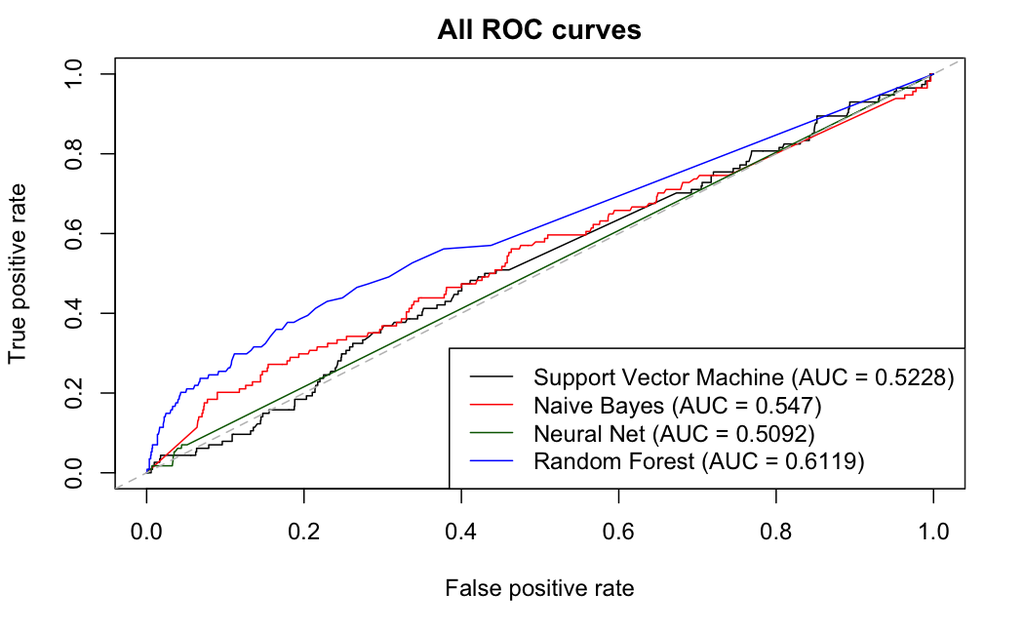

```r
abline(0,1, col = "grey", lty = 2)
legend("bottomright", legend = c(paste0("Support Vector Machine (AUC = ", auc_test_svm, ")"),
                                 paste0("Naive Bayes (AUC = ", auc_test_nb, ")"),
                                 paste0("Neural Net (AUC = ", auc_test_nn, ")"),
                                 paste0("Random Forest (AUC = ", auc_test_rf, ")")),
       col = c("black","red","darkgreen","blue"), lty = c(1,1,1,1))
```

### Plot Test-AUC vs Train-AUC

#### Naive Bayes Test vs Train ROC & AUC

```r
# Calculate values for train
pred_train_nb <- predict(nb_model, newdata = train, type = "raw")
prediction_train_nb <- ROCR::prediction(pred_train_nb[,2], labels = train$class)
roc_train_nb <- performance(prediction_train_nb, measure="tpr", x.measure="fpr")
auc_train_nb <- performance(prediction_train_nb, measure="auc")
auc_train_nb <- round(auc_train_nb@y.values[[1]], 4)
# Plot
plot(roc_train_nb, main = "Naive Bayes: Train-ROC vs Test-ROC")
plot(roc_test_nb, add = TRUE, col = "red")
```

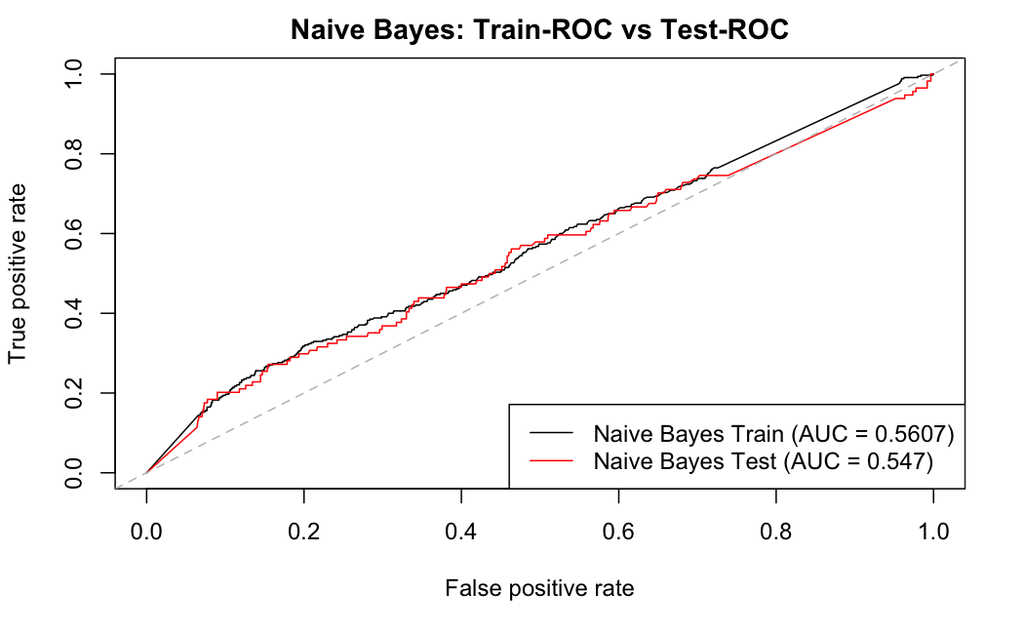

```r
abline(0,1, col = "grey", lty = 2)
legend("bottomright", legend = c(paste0("Naive Bayes Train (AUC = ", auc_train_nb, ")"),
                                 paste0("Naive Bayes Test (AUC = ", auc_test_nb, ")")),
       col = c("black", "red"), lty = c(1,1))
```

#### Random Forest Test vs Train ROC & AUC

```r
# Calculate values for train
pred_train_rf <- predict(rf_model, newdata = train, type = "prob")
prediction_train_rf <- ROCR::prediction(pred_train_rf[,2], labels = train$class)
roc_train_rf <- performance(prediction_train_rf, measure="tpr", x.measure="fpr")
auc_train_rf <- performance(prediction_train_rf, measure="auc")
auc_train_rf <- round(auc_train_rf@y.values[[1]], 4)
# Plot
plot(roc_train_rf, main = "Random Forest: Train-ROC vs Test-ROC")
plot(roc_test_rf, add = TRUE, col = "red")
```

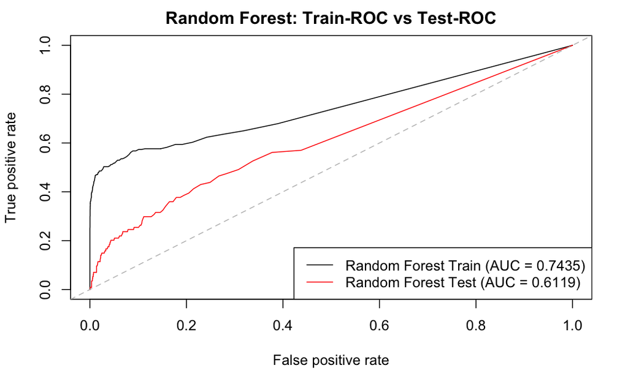

```r
abline(0,1, col = "grey", lty = 2)
legend("bottomright", legend = c(paste0("Random Forest Train (AUC = ", auc_train_rf, ")"),
                                 paste0("Random Forest Test (AUC = ", auc_test_rf, ")")),
       col = c("black", "red"), lty = c(1,1))
```

#### Neural Net Test vs Train ROC & AUC

```r
# Calculate values for train
pred_train_nn <- predict(nn_model, newdata = train, type = "prob")
prediction_train_nn <- ROCR::prediction(pred_train_nn[,2], labels = train$class)
roc_train_nn <- performance(prediction_train_nn, measure="tpr", x.measure="fpr")
auc_train_nn <- performance(prediction_train_nn, measure="auc")
auc_train_nn <- round(auc_train_nn@y.values[[1]], 4)
# Plot
plot(roc_train_nn, main = "Neural Net: Train-ROC vs Test-ROC")
plot(roc_test_nn, add = TRUE, col = "red")
```

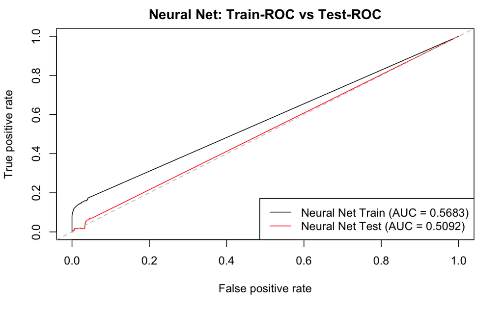

```r
abline(0,1, col = "grey", lty = 2)
legend("bottomright", legend = c(paste0("Neural Net Train (AUC = ", auc_train_nn, ")"),
                                 paste0("Neural Net Test (AUC = ", auc_test_nn, ")")),
       col = c("black", "red"), lty = c(1,1))
```

#### Support Vector Machine Test vs Train ROC & AUC

```r
# Calculate values for train
pred_train_svm <- predict(svm_model, newdata = train, type = "prob")
prediction_train_svm <- ROCR::prediction(pred_train_svm[,2], labels = train$class)
roc_train_svm <- performance(prediction_train_svm, measure="tpr", x.measure="fpr")
auc_train_svm <- performance(prediction_train_svm, measure="auc")
auc_train_svm <- round(auc_train_svm@y.values[[1]], 4)
# Plot
plot(roc_train_svm, main = "Neural Net: Train-ROC vs Test-ROC")
plot(roc_test_svm, add = TRUE, col = "red")
```

[figure not shown]

```r
abline(0,1, col = "grey", lty = 2)
legend("bottomright", legend = c(paste0("Neural Net Train (AUC = ", auc_train_svm, ")"),
                                 paste0("Neural Net Test (AUC = ", auc_test_svm, ")")),
       col = c("black", "red"), lty = c(1,1))
```

### Summary

For the model random forest the roc-curve between train and test is wide apart, which is a sign for overfitting. Also, neural net shows some signs for overfitting.